# [HW3]

# **Wykres do poprawy**

Wadliwy wykres pochodzi z TV Republika, dotyczy dofinansowania produkcji amunicji przez UE dla państw europejskich.

Data publikacji: 18.03.2024

Źródło: https://www.youtube.com/watch?v=su88YCXxUeA&t=68s

[figure not shown]

Na pierwszy rzut oka mogłoboby się wydawać, że jedyną wadą wykresu powyżej jest to, że jest on **kołowy**, jednak po dłuższej analizie można dostrzec, że niektóre **kolory obszarów uniemożliwiają poznanie szczegółowych informacji** odnośnie przyznanych pieniędzy na produkcję amunicji, jak np. pola dla Niemiec czy też Hiszpanii. Podpisy z nazwą państwa oraz udziałem procentowym powinny mimo wszystko ułatwiać widzowi odczytanie istotnych wiadomości, ale **brak informacji o jednostce** w jakiej dane są podane zarówno jako waluta jak i rząd wielkości nie upraszczają tego zadania. Inny problem, który wydaje się zastanawiający to **brak podanego źródła**, na podstawie którego wykres mógłby powstać.

# **Cel**

Poprawić wykres na słupkowy oraz zmienić jednostki na mln euro lub na udział procentowy z 500 mln euro (Na podstawie informacji z serwisów Bakier.pl oraz TVN24).

Baknier.pl: https://www.bankier.pl/wiadomosc/Dezamet-beneficjentem-srodkow-UE-Otrzyma-srodki-na-produkcje-amunicji-8712041.html

TVN24: https://tvn24.pl/polska/pieniadze-z-ue-na-produkcje-amunicji-jacek-siewiera-mamy-do-czynienia-ze-skandalem-mon-odpowiada-mariuszowi-blaszczakowi-st7824472

# **Propozycje wykresu**

Pierwszą propozycją wykresu jest wykres słupkowy przedstawiający ile mln euro zostało przeznaczonych na dany kraj europejski.

Kod do jego utworzenia wygląda następująco:

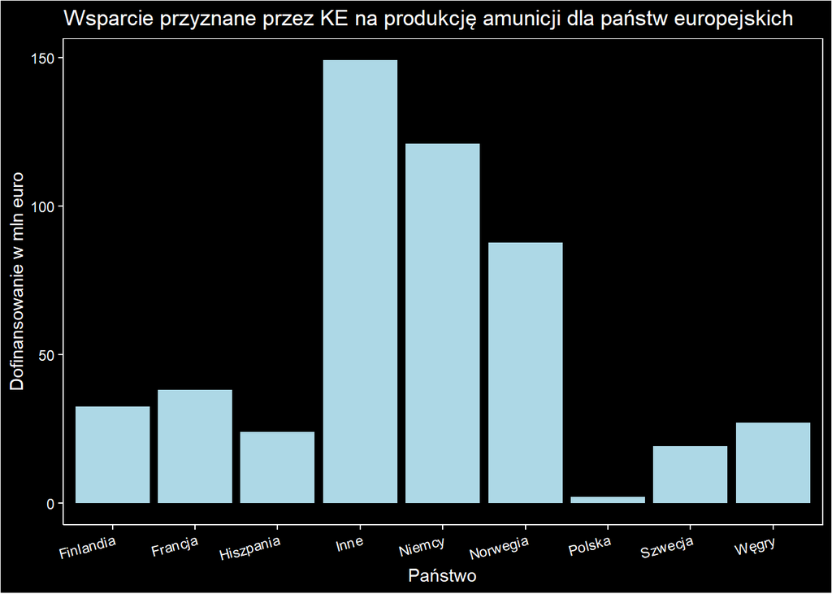

```r
df%>%
  ggplot(aes(x=Panstwo,y=Dofinansowanie))+
  geom_col(fill='lightblue')+
  labs(x="Państwo",
       y = "Dofinansowanie w mln euro",
       title = "Wsparcie przyznane przez KE na produkcję amunicji dla państw europejskich ")+
  theme_bw()+
  theme(panel.background = element_rect(fill="black"),
        panel.grid = element_blank(),
        plot.background =element_rect(fill="black"),text = element_text(color="white"),
        axis.text=element_text(color="white"),
        axis.line=element_line(color="white"),
        axis.ticks =element_line(color="white"),
        panel.border = element_rect(color="white"))+
  scale_x_discrete(guide = guide_axis(angle = 15))
```

Drugą propozycją wykresu jest wykres słupkowy przedstawiający jaki odsetek z 500 mln euro został przeznaczony na dane państwo europejskie.

Kod do jego utworzenia wygląda następująco:

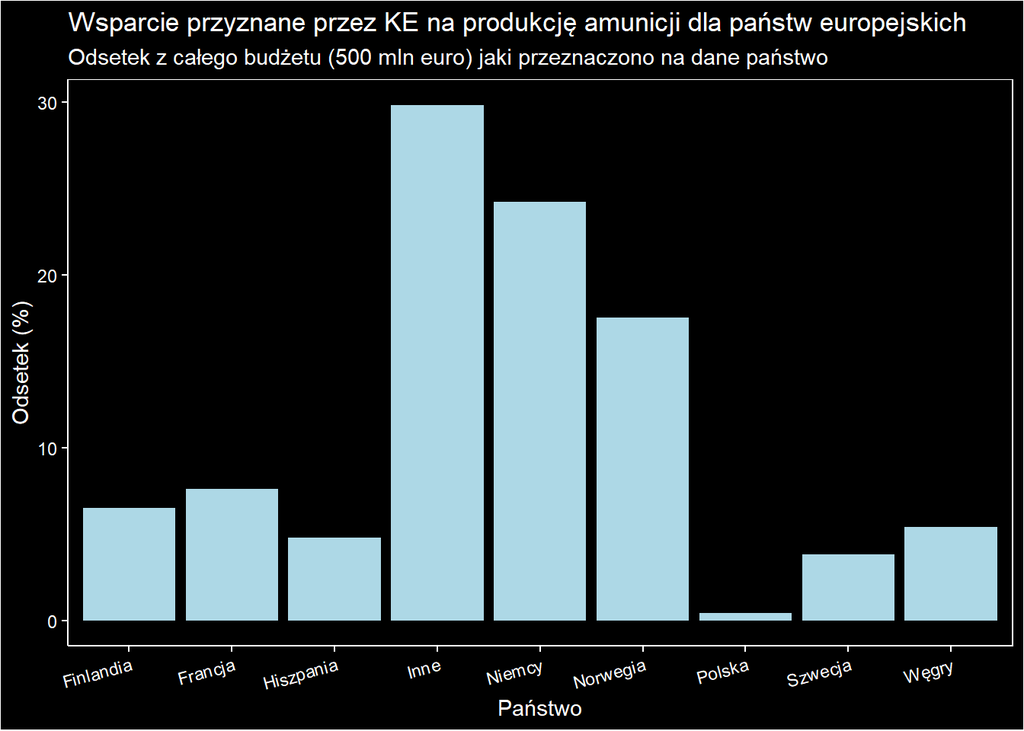

```r
df%>%
  mutate(Procent=(Dofinansowanie/5))%>%
  ggplot(aes(x=Panstwo,y=Procent))+
  geom_col(fill='lightblue')+
  labs(x="Państwo",
       y = "Odsetek (%)",
       title = "Wsparcie przyznane przez KE na produkcję amunicji dla państw europejskich ",
       subtitle = "Odsetek z całego budżetu (500 mln euro) jaki przeznaczono na dane państwo")+
  theme_bw()+
  theme(panel.background = element_rect(fill="black"),
        panel.grid = element_blank(),
        plot.background =element_rect(fill="black"),text = element_text(color="white"),
        axis.text=element_text(color="white"),
        axis.line=element_line(color="white"),
        axis.ticks =element_line(color="white"),
        panel.border = element_rect(color="white"))+
  scale_x_discrete(guide = guide_axis(angle = 15))
```

# **Uzasadnienie**

Proponowane wizualizacje zdecydowanie czytelniej pokazują dofinansowanie wybranych państw europejskich. Widz nie ma wątpliwości ile mln euro zostało przeznaczonych na dany kraj. Co więcej z wykresu można odczytać jakiej waluty, a także jakiego rzędu są omawiane dane.

# **Ciekawostka**

Według innych źródeł informacji takich jak TVN24, Bankier.pl, czy też TVP info. Niemcy otrzymały dofinansowanie wysokości 85 mln euro. Możnaby podejrzewać, że niewyraźny wykres może maskować ewentualne nieporozumienie. Co więcej błąd mógłby wynikać z sumowania rzeczywistego dofinansowania dla firm niemieckich wraz z konsorcjami firm, w których niemieckie firmy współuczestniczą. Jednak i to nie prowadzi do tych samych danych otrzymanych przez TV Republika. Niestety sprzeczne dane z pozstałymi serwisami informacyjnymi pozostaną zagadką…

TVP info: https://www.tvp.info/76468097/ke-przeznacza-500-mln-euro-na-produkcje-amunicji-asap-polski-dezamet-otrzyma-ulamek-budzetu